# Example HDRUK 4C-Readm. Health Data Analysis

2023-08-24

## Descriptive Statistics of Dummy Admitted Patient Care Dataset

- Dummy patient data used, an approximation of English APC data. 100K rows, 38 variables. 26 Variables based off of 4C_mortality_score/01_data_prep.R script. For example: dialysis; age.factor; hypertension_mhyn. Remaining 12 variables generated by memory and ICD package, such as dates and causes of first readmission. Date range, 1st March 2020 - 1st March 2022.
- **50,023, 50%** are readmitted and **12,630, 12.6%** are readmitted within 90 days. Of those readmitted, **25.2%** are readmitted within 90 days of discharge. Not too dissimilar to Ramzi 2022 meta-analyses, **9.79%** prevalence of 90-day readmissions (10.1016/j.ajem.2021.10.059).
- **4,215, 4.22%** patients died in total before readmission and **546, 0.55%** died within 90 days of discharge. Of those patients that died, **12.95%** died within 90 days. Real patient data more likely to have a much higher % of patients dying before readmission, within 90 days.(https://www.washingtonpost.com/health/2023/08/21/long-covid-lingering-effects-two-years-later/)
- **8,441, 8.44%** patients died in total and **1045, 1.04%** died within 90 days of discharge. Of those patients that died, **12.4%** died within 90 days.The prevalence of 90 day post-discharge all-cause mortality dissimilar to Ramzi 2022 figure of **7.63%** (10.1016/j.ajem.2021.10.059).

## Top 10 Causes of Readmission

| Cause of Readmission Group | no.Readmissions | Proportion | Cumulative Proportion |
| --- | --- | --- | --- |
| COVID-19 | 20,059 | 45.4% | 45.4% |
| Diseases of the respiratory system | 7,857 | 17.8% | 63.2% |
| Diseases of the circulatory system | 5,625 | 12.7% | 75.9% |
| Symptoms, signs and abnormal clinical and laboratory findings, not elsewhere classified | 3,275 | 7.42% | 83.32% |
| External causes of morbidity | 2,087 | 4.73% | 88.05% |
| Injury, poisoning and certain other consequences of external causes | 1,362 | 3.09% | 91.14% |
| Certain infectious and parasitic diseases | 1,293 | 2.93% | 94.07% |
| Neoplasms | 1,145 | 2.59% | 96.66% |
| Congenital malformations, deformations and chromosomal abnormalities | 743 | 1.68% | 98.34% |
| Factors influencing health status and contact with health services | 702 | 1.59% | 99.93% |
| Total | 44,148 | 99.93% |  |

## Top 10 Causes of Death

| Cause of Death Group | no.Deaths | Proportion | Cumulative Proportion |
| --- | --- | --- | --- |
| COVID-19 | 3,752 | 49.8% | 49.8% |
| Mental, Behavioral and Neurodevelopmental disorders | 1,645 | 21.8% | 71.6% |
| Diseases of the respiratory system | 872 | 11.6% | 83.2% |
| External causes of morbidity | 311 | 4.12% | 87.32% |
| Injury, poisoning and certain other consequences of external causes | 226 | 3% | 90.32% |
| Certain infectious and parasitic diseases | 207 | 2.75% | 93.07% |
| Neoplasms | 186 | 2.47% | 95.54% |
| Symptoms, signs and abnormal clinical and laboratory findings, not elsewhere classified | 122 | 1.62% | 97.16% |
| Factors influencing health status and contact with health services | 117 | 1.55% | 98.71% |
| Congenital malformations, deformations and chromosomal abnormalities | 102 | 1.35% | 100.06% |
| Total | 7,540 | 100.06% |  |

## Full Cohort Survival Probability for all Deaths

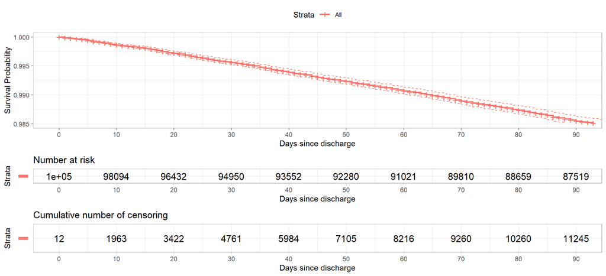

## Male vs Female Survival Probability for all Deaths

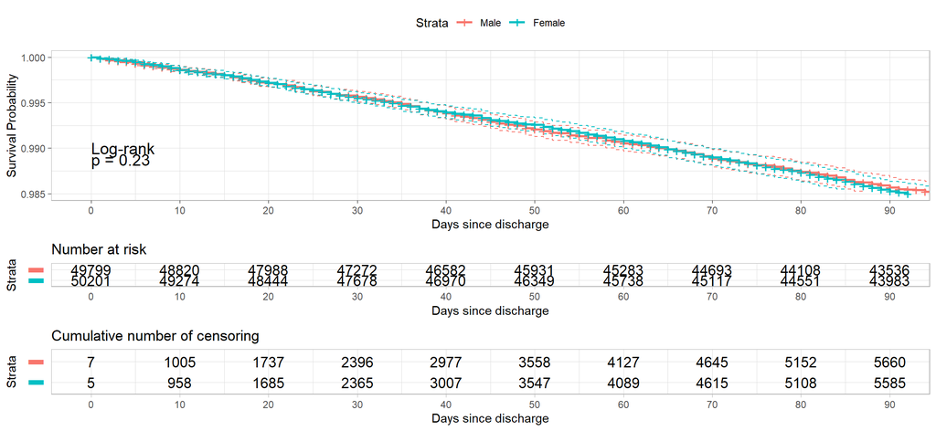

## Cumulative Incidence of Readmissions and Deaths

[figure not shown]

## Cox-proportional Hazards Regression - All Causes of Readmission HR Plot

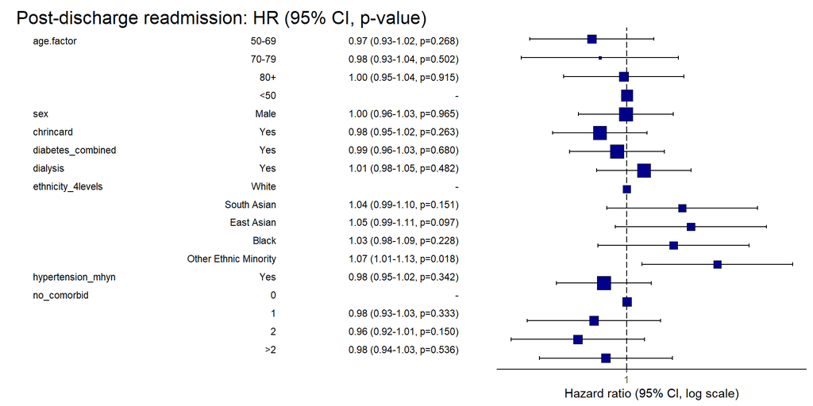

[output not shown]